# Exploratory Data Analysis

## Two continuous variables

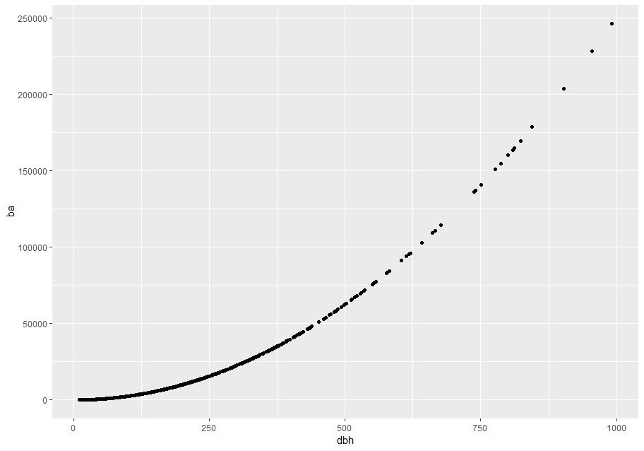

```r
error <- rnorm(length(stem$dbh))
stem <- stem %>%
  mutate(ba = (1 / 4 * (dbh)^2) + error)

p <- ggplot(stem, aes(dbh, ba))
p + geom_point()
```

Scatterplots become less useful as the size of your dataset grows, because points begin to overplot and pile up into areas of uniform black (as above). You have already seen one way to fix the problem: using the `alpha` aesthetic to add transparency.

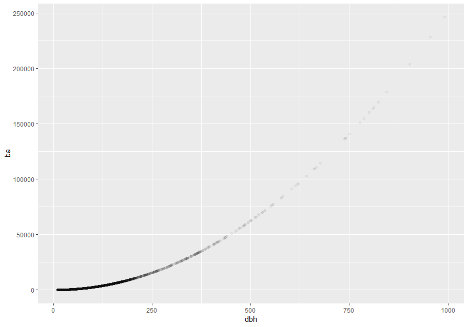

```r
p + geom_point(alpha = 1 / 25)
```

But using transparency can be challenging for very large datasets. Another solution is to use `bin`. Previously, you used `geom_histogram()` and `geom_freqpoly()` to bin in one dimension. Now, you will learn how to use `geom_bin2d()` and `geom_hex()` to bin in two dimensions.

`geom_bin2d()` and `geom_hex()` divide the coordinate plane into 2d bins and then use a fill color to display how many points fall into each bin. `geom_bin2d()` creates rectangular bins. `geom_hex()` creates hexagonal bins. You will need to install the **hexbin** package to use `geom_hex()`.

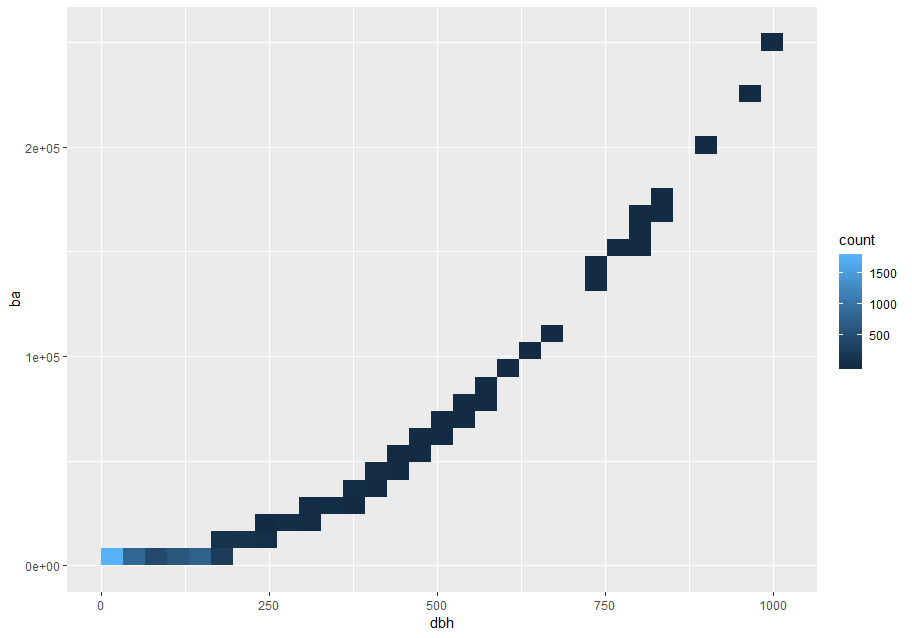

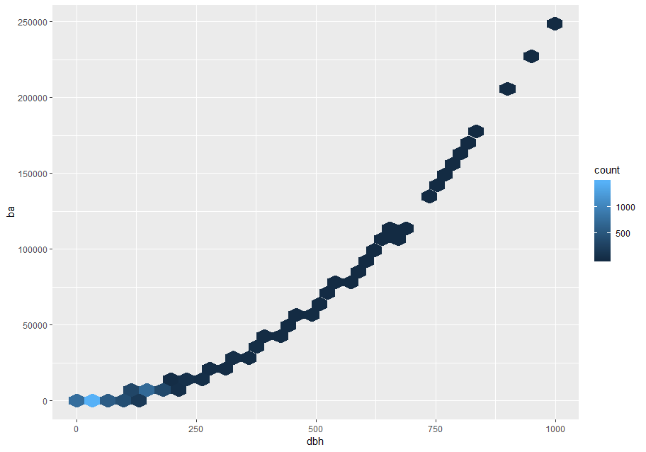

```r
# Remember to install with install.packages("hexbin")
# Left
p + geom_bin2d()
# Right
p + geom_hex()
```

Another option is to bin one continuous variable so it acts like a categorical variable. Then, you can use one of the techniques for visualizing the combination of a categorical and a continuous variable that you learned about. For example, you can bin `dbh` and then display a boxplot for each group:

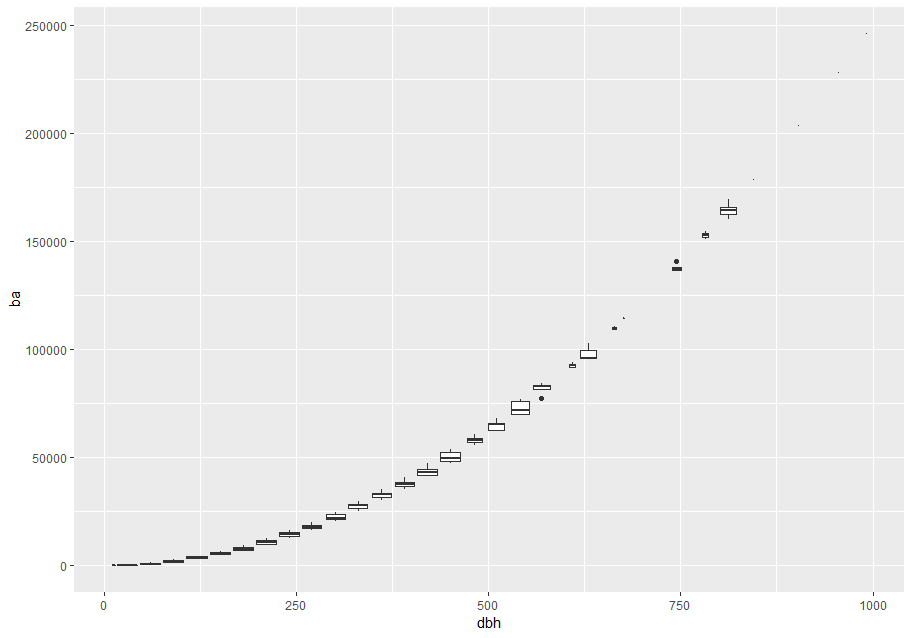

```r
p <- ggplot(stem, aes(dbh, ba))
p + geom_boxplot(aes(group = cut_width(dbh, useful_binwidth)))
```

`cut_width(x, width)`, as used above, divides x into bins of width `width`. By default, boxplots look roughly the same (apart from number of outliers) regardless of how many observations there are; therefore, it is difficult to tell that each boxplot summarizes a different number of points. One way to show that is to make the width of the boxplot proportional to the number of points with `varwidth = TRUE`.

Another approach is to display approximately the same number of points in each bin. That is the job of `cut_number()`:

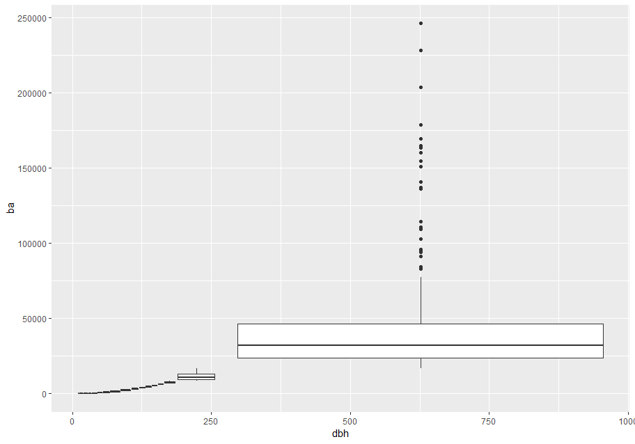

```r
p + geom_boxplot(aes(group = cut_number(dbh, 20)))
```

## Patterns and models

Patterns in your data provide clues about relationships. If a systematic relationship exists between two variables, it will appear as a pattern in the data. If you spot a pattern, ask yourself:

- Could this pattern be due to coincidence (i.e. random chance)?
- How can you describe the relationship implied by the pattern?
- How strong is the relationship implied by the pattern?
- What other variables might affect the relationship?
- Does the relationship change if you look at individual subgroups of the data?

Above, we learned that a scatterplot of stem diameter (`dbh`) versus basal area (`ba`) shows a pattern: larger stem diameters are associated with larger basal area.

Patterns provide one of the most useful tools for data scientists, because they reveal covariation. If you think of variation as a phenomenon that creates uncertainty, covariation is a phenomenon that reduces it. If two variables co-vary, you can use the values of one variable to make better predictions about the values of the second. If the covariation is due to a causal relationship (a special case), then you can use the value of one variable to control the value of the second.

Models are a tool for extracting patterns out of data. For example, consider the `stem` data; `dbh` and `ba` are tightly related. It is possible to use a model to remove the very strong relationship between `dbh` and `ba` so we can explore the subtleties that remain. The following code fits a model that predicts `ba` from `dbh` and then computes the residuals (the difference between the predicted value and the actual value). The residuals give us a view of the basal area of a stem, once the effect of `dbh` has been removed.

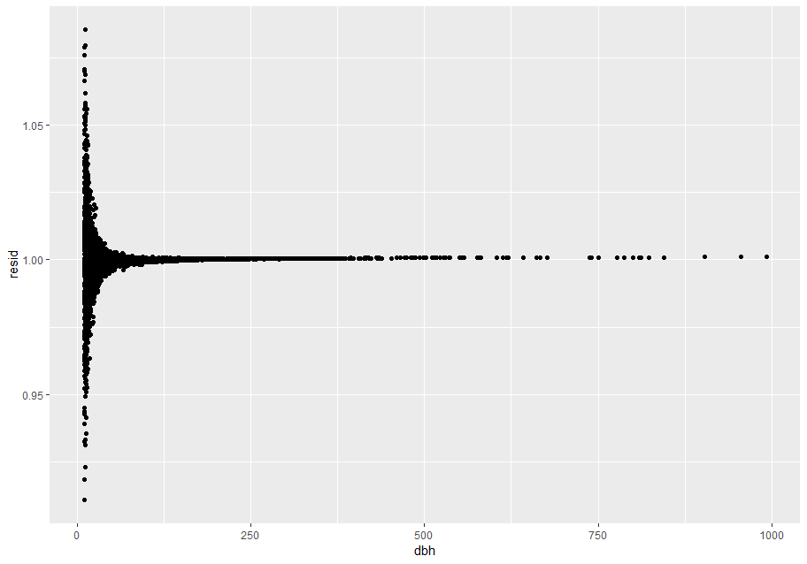

```r
library(modelr)

mod <- lm(log(ba) ~ log(dbh), data = stem)
resid_added <- stem %>%
  add_residuals(mod) %>%
  mutate(resid = exp(resid))

ggplot(data = resid_added, aes(x = dbh, y = resid)) +
  geom_point()
```